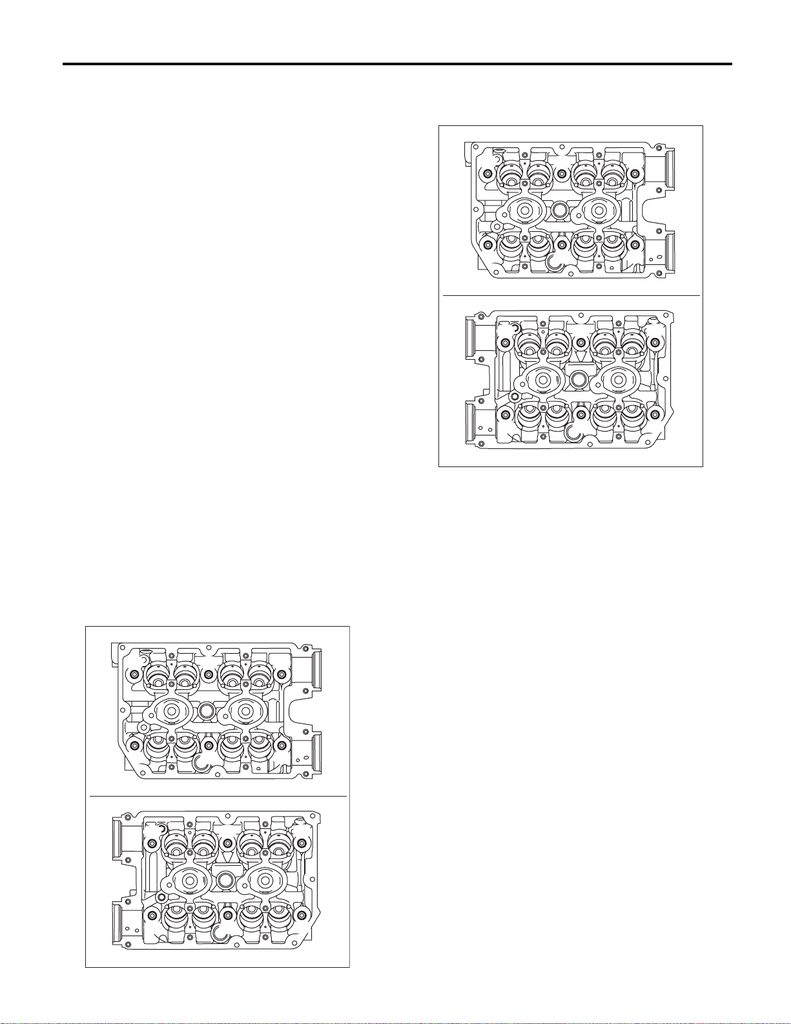

ME(STI)-70

Cylinder Head

MECHANICAL

19.Cylinder Head

A: REMOVAL

1) Remove the engine from the vehicle. <Ref. to

ME(STI)-30, REMOVAL, Engine Assembly.>

2) Remove the rear side belt. <Ref. to ME(STI)-41,

REAR SIDE BELT, REMOVAL, V-belt.>

3) Remove the intake manifold. <Ref. to FU(STI)-

17, REMOVAL, Intake Manifold.>

4) Remove the crank pulley. <Ref. to ME(STI)-48,

REMOVAL, Crank Pulley.>

5) Remove the timing belt cover. <Ref. to ME(STI)-

50, REMOVAL, Timing Belt Cover.>

6) Remove the timing belt. <Ref. to ME(STI)-51,

REMOVAL, Timing Belt.>

7) Remove the cam sprocket. <Ref. to ME(STI)-60,

REMOVAL, Cam Sprocket.>

8) Remove the secondary air combination valve.

<Ref. to EC(STI)-54, REMOVAL, Secondary Air

Combination Valve.>

9) Remove the bolts which secure A/C compressor

bracket to cylinder head.

10) Remove the oil pipe. <Ref. to LU(STI)-24, RE-

MOVAL, Oil Pipe.>

11) Remove the camshaft. <Ref. to ME(STI)-62,

REMOVAL, Camshaft.>

12) Remove the oil level gauge guide. (LH side

only)

13) Remove the cylinder head bolts in alphabetical

order shown in the figure.

NOTE:

Leave the bolts (A) and (D) engaged by three or

four threads to prevent the cylinder head from fall-

ing.

14) While tapping the cylinder head with a plastic

hammer, separate it from cylinder block. Remove

the bolts (A) and (D) to remove cylinder head.

15) Remove the cylinder head gasket.

CAUTION:

Be careful not to scratch the mating surface of

cylinder head and cylinder block.

B: INSTALLATION

1) Install the cylinder head to the cylinder block.

CAUTION:

Be careful not to scratch the mating surface of

cylinder head and cylinder block.

NOTE:

Use a new cylinder head gasket.

(1) Clean the bolt threads and the bolt holes in

the cylinder block.

CAUTION:

To avoid erroneous tightening of the bolts,

clean out the bolt holes sufficiently by blowing

with compressed air to eliminate engine cool-

ant etc.

(2) Apply a sufficient coat of engine oil to the

washer and bolt thread.

(3) Tighten all bolts to 40 N·m (4.1 kgf-m, 29.5

ft-lb) in alphabetical order.

ME-05983

(F) (D)

(C)

(E)

(B)

(D)

(F)

(A)

(B)

(E)

(C)

(A)

ME-05983

(F) (D)

(C)

(E)

(B)

(D)

(F)

(A)

(B)

(E)

(C)

(A)

15WRX_STI_US_EN.book 70 ページ ２０１５年２月１３日 金曜日 午前１１時２０分

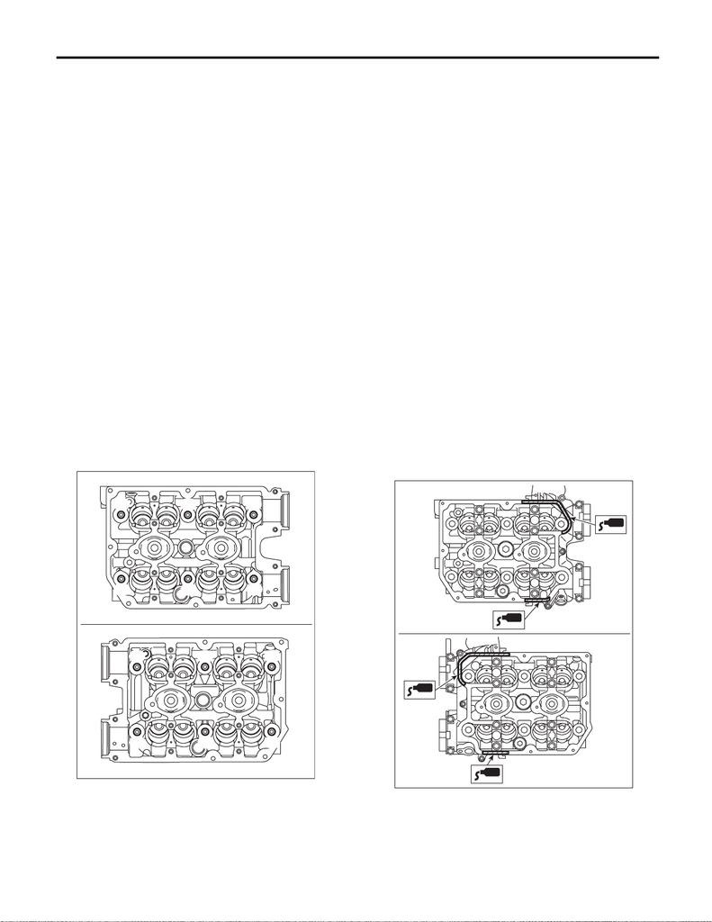

ME(STI)-71

Cylinder Head

MECHANICAL

(4) Retighten all bolts to 95 N·m (9.7 kgf-m,

70.1 ft-lb) in alphabetical order.

CAUTION:

If the bolt makes stick-slip sound during tight-

ening, repeat the procedure from step (1). In

this case, the cylinder head gasket can be re-

used.

(5) Loosen all the bolts by 180° in the reverse

order of installing, and loosen them further by

180°.

(6) Tighten all bolts to 10 N·m (1.0 kgf-m, 7.4 ft-lb)

in alphabetical order.

(7) Retighten all bolts to 30 N·m (3.1 kgf-m,

22.1 ft-lb) in alphabetical order.

(8) Retighten all bolts to 70 N·m (7.1 kgf-m,

51.6 ft-lb) in alphabetical order.

(9) Retighten all bolts by 80 — 90° in alphabet-

ical order.

(10) Retighten all bolts by 40 — 45° in alphabet-

ical order.

CAUTION:

The tightening angle of the bolt should not ex-

ceed 45°.

(11) Retighten bolts (A) and (B) by 40 — 45°.

CAUTION:

Make sure the total “tightening angle” of steps

(10) and (11) does not exceed 90°.

2) Install the oil level gauge guide. (LH side only)

Tightening torque:

6.4 N·m (0.7 kgf-m, 4.7 ft-lb)

3) Install the camshaft. <Ref. to ME(STI)-64, IN-

STALLATION, Camshaft.>

4) Install the oil pipe. <Ref. to LU(STI)-26, INSTAL-

LATION, Oil Pipe.>

5) Install the A/C compressor bracket on cylinder

head.

Tightening torque:

36 N·m (3.7 kgf-m, 26.6 ft-lb)

6) Install the secondary air combination valve.

<Ref. to EC(STI)-54, INSTALLATION, Secondary

Air Combination Valve.>

7) Install the cam sprocket. <Ref. to ME(STI)-60,

INSTALLATION, Cam Sprocket.>

8) Install the timing belt. <Ref. to ME(STI)-53, IN-

STALLATION, Timing Belt.>

9) Adjust the valve clearance. <Ref. to ME(STI)-29,

ADJUSTMENT, Valve Clearance.>

10) Install the rocker cover.

(1) Install the rocker cover gasket to the rocker

cover. (outer section and ignition coil section)

NOTE:

Use a new rocker cover gasket.

(2) Apply liquid gasket to the specified point of

the cylinder head.

NOTE:

Install within 5 min. after applying liquid gasket.

Liquid gasket:

THREE BOND 1217G (Part No. K0877Y0100)

or equivalent

(3) Install the rocker cover onto cylinder heads.

Ensure the gasket is properly positioned during

installation.

ME-05984

(F)

(A) (C)

(D)

(B)

(E)

(C)

(A)

(F)

(E)

(B)

(D)

ME-05981

15WRX_STI_US_EN.book 71 ページ ２０１５年２月１３日 金曜日 午前１１時２０分

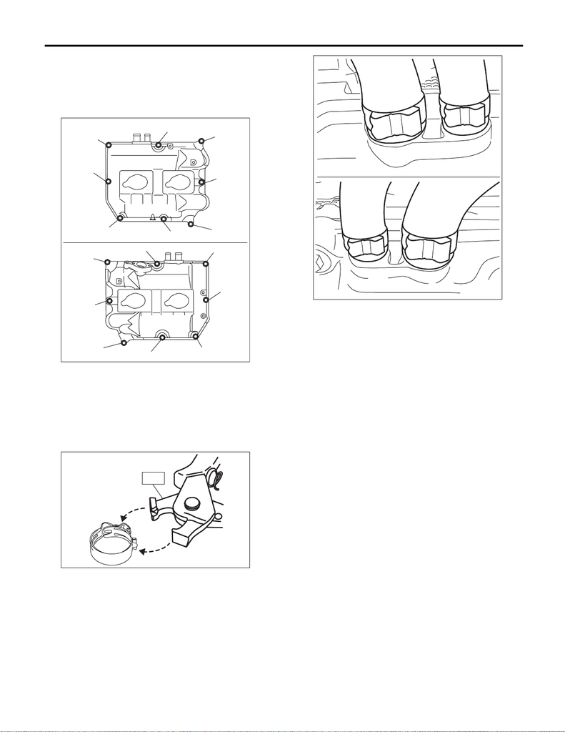

ME(STI)-72

Cylinder Head

MECHANICAL

(4) Temporarily tighten the rocker cover bolts in

alphabetical order shown in the figure, and then

tighten to specified torque in alphabetical order.

Tightening torque:

6.4 N·m (0.7 kgf-m, 4.7 ft-lb)

11) Connect the PCV hose (A) and vacuum hose

(B) to the rocker cover.

NOTE:

Use a new clamp, fit the cut out in the ST with the

protrusion on the clamp as shown in the figure, and

lock the clamp.

ST 18353AA000 CLAMP PLIERS

12) Install the timing belt cover. <Ref. to ME(STI)-

50, INSTALLATION, Timing Belt Cover.>

13) Install the crank pulley. <Ref. to ME(STI)-48,

INSTALLATION, Crank Pulley.>

14) Install the intake manifold. <Ref. to FU(STI)-21,

INSTALLATION, Intake Manifold.>

15) Install the rear side belt. <Ref. to ME(STI)-42,

REAR SIDE BELT, INSTALLATION, V-belt.>

16) Install the engine to the vehicle. <Ref. to

ME(STI)-34, INSTALLATION, Engine Assembly.>

ME-05982

(E)

(F)

(H)

(G)

(D),(L)

(A),(I)

(C),(K)

(B),(J)

(B),(J)

(H)

(F)

(C),(K)

(E)

(A),(I)

(D),(L)

(G)

ME-08033

ST

ME-07960

(A)

(A)

(B)

(B)

15WRX_STI_US_EN.book 72 ページ ２０１５年２月１３日 金曜日 午前１１時２０分

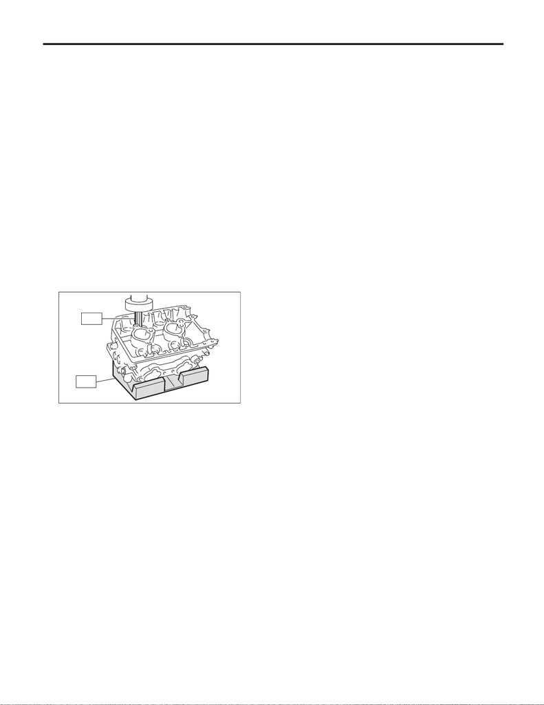

ME(STI)-73

Cylinder Head

MECHANICAL

C: DISASSEMBLY

1) Remove the valve lifter.

2) Place the cylinder head on ST1.

ST1 498267600 CYLINDER HEAD TABLE

3) Using ST2, compress the valve spring and re-

move the valve spring retainer key. Remove each

valve and valve spring.

ST2 499718000 VALVE SPRING REMOVER

NOTE:

• Mark each valve to prevent confusion.

• Pay careful attention not to damage the lips of in-

take valve oil seals and exhaust valve oil seals.

• Keep all the removed parts in order for re-install-

ing in their original positions.

• For removal and installation procedures of the

valve guide, intake valve oil seal and exhaust valve

oil seal, refer to “INSPECTION”. <Ref. to ME(STI)-

76, VALVE GUIDE, INSPECTION, Cylinder

Head.> <Ref. to ME(STI)-78, INTAKE AND EX-

HAUST VALVE OIL SEAL, INSPECTION, Cylinder

Head.>

ME-05003

ST1

ST2

15WRX_STI_US_EN.book 73 ページ ２０１５年２月１３日 金曜日 午前１１時２０分

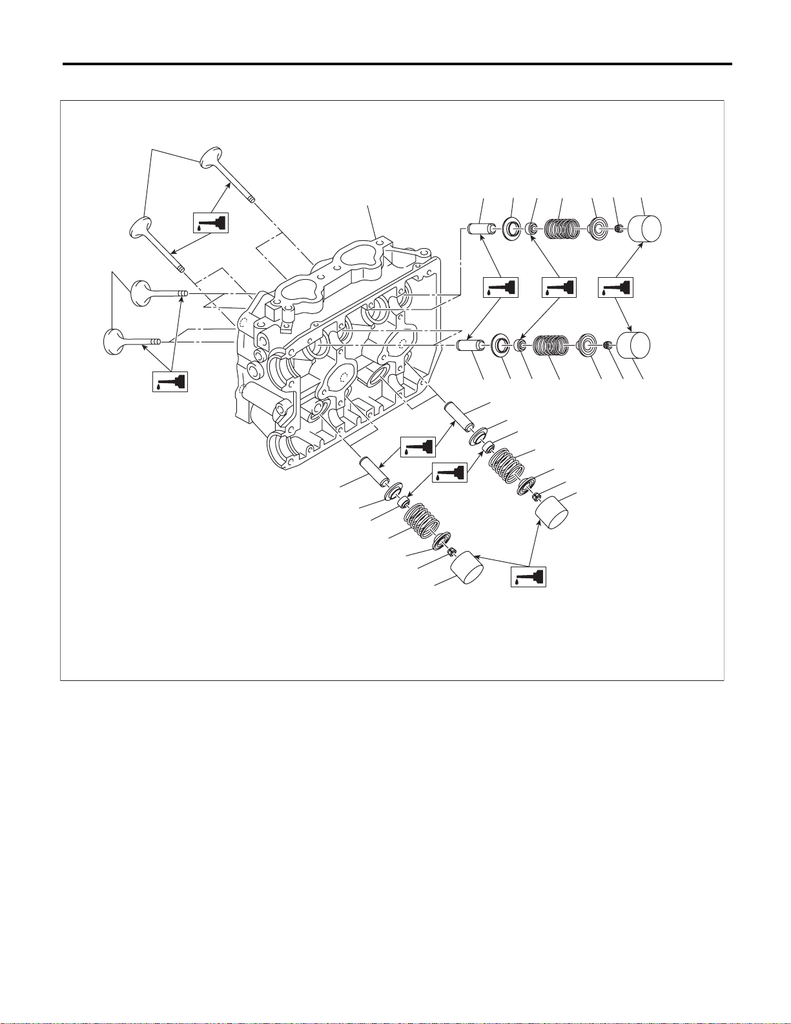

ME(STI)-74

Cylinder Head

MECHANICAL

D: ASSEMBLY

(1) Exhaust valve (5) Intake valve oil seal (9) Valve lifter

(2) Intake valve (6) Valve spring (10) Exhaust valve oil seal

(3) Cylinder head (7) Valve spring retainer (11) Intake valve guide

(4) Valve spring seat (8) Valve spring retainer key (12) Exhaust valve guide

(3)

(1)

(12)

(10)

(4)

(6)

(7)

(8)

(9)

(10)

(4)

(6)

(7)

(8)

(9)

ME-04990

(12)

(2)

(11)

(4)

(5)

(6)

(7)

(8)

(9)

(11)

(4)

(5)

(6)

(7)

(8)

(9)

15WRX_STI_US_EN.book 74 ページ ２０１５年２月１３日 金曜日 午前１１時２０分

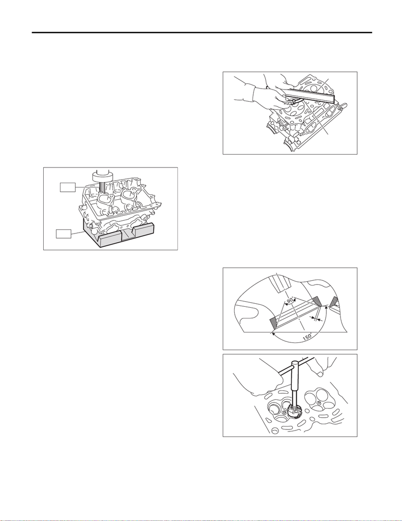

ME(STI)-75

Cylinder Head

MECHANICAL

1) Install the valve spring and valve.

(1) Coat the valve stem of each valve with en-

gine oil and insert the valve into valve guide.

NOTE:

When inserting the valve into valve guide, use spe-

cial care not to damage the oil seal lip.

(2) Set the cylinder head on ST1.

ST1 498267600 CYLINDER HEAD TABLE

(3) Install the valve spring and valve spring re-

tainer.

NOTE:

Be sure to install the valve spring with its close-

coiled end facing the cylinder head side.

(4) Set the ST2 on valve spring.

ST2 499718000 VALVE SPRING REMOVER

(5) Compress the valve spring and fit the valve

spring retainer key.

(6) After installing, tap the valve spring retainers

lightly with a plastic hammer for better seating.

2) Apply oil to the surface of valve lifter.

3) Install the valve lifter.

E: INSPECTION

1. CYLINDER HEAD

1) Check for cracks or damage. Use liquid pene-

trant tester on the important sections to check for

fissures. Check that there are no marks of gas leak-

ing or water leaking on gasket installing surface.

2) Measure the warping of the cylinder head sur-

face that mates with cylinder block using a straight

edge (A) and thickness gauge (B).

If the warping exceeds the limit, correct the surface

by grinding it with a surface grinder.

Warping limit:

0.035 mm (0.0014 in)

Grinding limit:

0.3 mm (0.012 in)

Standard height of cylinder head:

127.5 mm (5.02 in)

NOTE:

Uneven torque for the cylinder head bolts can

cause warping. When reinstalling, pay special at-

tention to the torque so as to tighten evenly.

2. VALVE SEAT

Inspect the intake and exhaust valve seats, and

correct the contact surfaces with a valve seat cutter

if they are defective or when valve guides are re-

placed.

Contacting width W between valve and valve

seat:

Standard

Intake

0.6 — 1.4 mm (0.024 — 0.055 in)

Exhaust

1.2 — 1.8 mm (0.047 — 0.071 in)

ME-05003

ST1

ST2

ME-00126

(A)

(B)

ME-04721

W

ME-00287

15WRX_STI_US_EN.book 75 ページ ２０１５年２月１３日 金曜日 午前１１時２０分

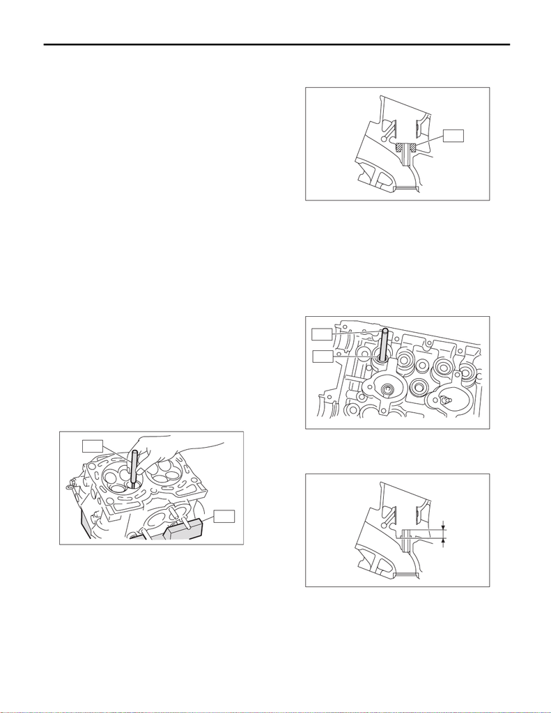

ME(STI)-76

Cylinder Head

MECHANICAL

3. VALVE GUIDE

1) Check the clearance between valve guide and

valve stem. The clearance can be checked by mea-

suring respectively the outer diameter of valve

stem with a micrometer and the inner diameter of

valve guide with a caliper gauge.

Clearance between the valve guide and valve

stem:

Standard

Intake

0.030 — 0.057 mm (0.0012 — 0.0022 in)

Exhaust

0.040 — 0.067 mm (0.0016 — 0.0026 in)

2) If the clearance between valve guide and valve

stem exceeds the standard, replace the valve

guide or valve itself, whichever shows the greater

amount of wear or damage. See the following pro-

cedure for valve guide replacement.

Valve guide inner diameter:

6.000 — 6.012 mm (0.2362 — 0.2367 in)

Valve stem outer diameters:

Intake

5.955 — 5.970 mm (0.2344 — 0.2350 in)

Exhaust

5.945 — 5.960 mm (0.2341 — 0.2346 in)

(1) Place the cylinder head on ST1 with the

combustion chamber upward so that valve

guides fit the holes in ST1.

(2) Insert the ST2 into valve guide and press it

down to remove the valve guide.

ST1 498267600 CYLINDER HEAD TABLE

ST2 499767200 VALVE GUIDE REMOVER

(3) Turn the cylinder head upside down and

place the ST as shown in the figure.

ST 18251AA020 VALVE GUIDE ADJUSTER

(4) Before installing a new valve guide, make

sure that neither scratches nor damages exist

on the inner surface of valve guide holes in cyl-

inder head.

(5) Put a new valve guide, coated with sufficient

oil, in the cylinder head, and insert the ST1 into

valve guide. Press in until the valve guide upper

end is flush with the upper surface of ST2.

ST1 499767200 VALVE GUIDE REMOVER

ST2 18251AA020 VALVE GUIDE ADJUSTER

(6) Check the valve guide protrusion amount “L”.

Valve guide protrusion amount L:

15.8 — 16.2 mm (0.622 — 0.638 in)

ME-05004

ST1

ST2

ST

ME-04107

ME-00130

ST1

ST2

L

ME-04522

15WRX_STI_US_EN.book 76 ページ ２０１５年２月１３日 金曜日 午前１１時２０分

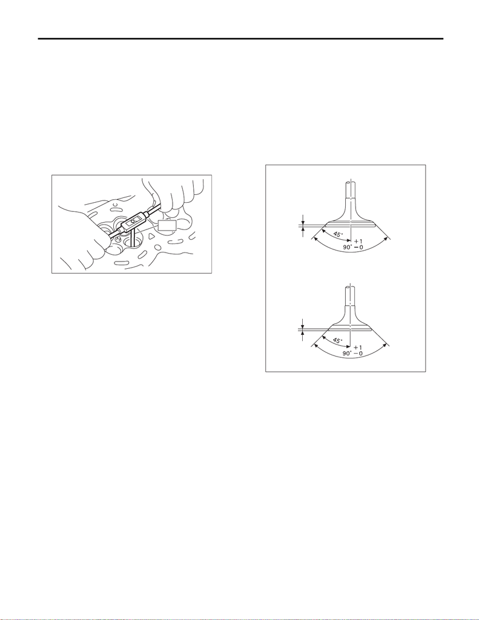

ME(STI)-77

Cylinder Head

MECHANICAL

(7) Ream the inside of valve guide using ST.

Put the ST in valve guide, and rotate the ST

slowly clockwise while pushing it lightly. Bring

the ST back while rotating it clockwise.

NOTE:

• Apply engine oil to the ST when reaming.

• If the inner surface of valve guide is damaged,

the edge of ST should be slightly ground with oil

stone.

• If the inner surface of valve guide becomes lus-

trous and the ST does not chip, use a new ST or

remedy the ST.

ST 499767400 VALVE GUIDE REAMER

(8) After reaming, clean the valve guide to re-

move chips.

(9) Recheck the contact condition between

valve and valve seat after replacing the valve

guide.

4. INTAKE AND EXHAUST VALVE

1) Inspect the flange of valve and valve stem, and

replace the valve with a new part if damaged, worn,

deformed, or if dimension “H” in the figure is out-

side of the specified limit.

Head edge thickness H:

Standard

Intake (A)

1.0 — 1.4 mm (0.039 — 0.055 in)

Exhaust (B)

1.3 — 1.7 mm (0.051 — 0.067 in)

2) Put a small amount of grinding compound on the

valve seat surface, and lap the valve and valve seat

surface. Replace with a new valve oil seal after lap-

ping.

NOTE:

It is possible to differentiate between the intake

valve and the exhaust valve by their overall length.

Valve overall length:

Intake

104.4 mm (4.110 in)

Exhaust

104.65 mm (4.1201 in)

ME-04393

ST

ME-04825

(B

)

(A)

H

H

15WRX_STI_US_EN.book 77 ページ ２０１５年２月１３日 金曜日 午前１１時２０分

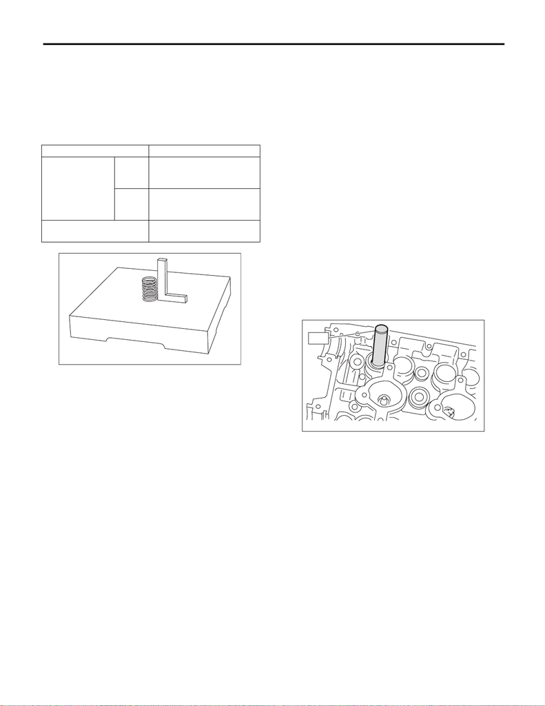

ME(STI)-78

Cylinder Head

MECHANICAL

5. VALVE SPRING

1) Check the valve springs for damage, free length,

and tension. Replace the valve spring if it is not

within the standard value presented in the table.

2) To measure the squareness of the valve spring,

stand the valve spring on a surface plate and mea-

sure its deflection at the top of the valve spring us-

ing a try square.

6. INTAKE AND EXHAUST VALVE OIL

SEAL

1) For the following, replace the oil seal with a new

part. See the procedure 2) and subsequent for re-

placement procedures.

• When the lip is damaged.

• When the spring is out of the specified position.

• When readjusting the surfaces of valve and

valve seat.

• When replacing the valve guide.

2) Place the cylinder head on ST1, and use ST2 to

press-fit the oil seal.

ST1 498267600 CYLINDER HEAD TABLE

ST2 498857100 VALVE OIL SEAL GUIDE

NOTE:

• Apply engine oil to oil seal before press-fitting.

• When press-fitting the oil seal, do not use a ham-

mer to strike in.

• The intake valve oil seals and exhaust valve oil

seals are distinguished by their colors.

Color of rubber part:

Intake [Gray]

Exhaust [Green]

Free length mm (in) 53.48 (2.106)

Tension/spring

height

N (kgf, lbf)/mm (in)

Set

204.6 — 235.4 (20.86 —

24.00, 46.00 — 52.93)/36.0

(1.417)

Lift

363.5 — 401.7 (37.07 —

40.96, 81.73 — 90.32)/26.7

(1.051)

Squareness

2.5°, 2.3 mm (0.091 in) or

less

ME-00283

ME-00133

ST2

15WRX_STI_US_EN.book 78 ページ ２０１５年２月１３日 金曜日 午前１１時２０分

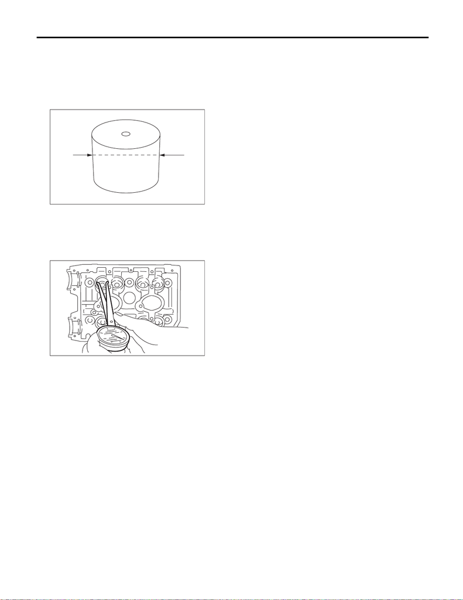

ME(STI)-79

Cylinder Head

MECHANICAL

7. VALVE LIFTER

1) Check the valve lifter visually.

2) Measure the outer diameter of valve lifter.

Outer diameter of valve lifter:

Standard

34.959 — 34.975 mm (1.3763 — 1.3770 in)

3) Measure the inner diameter of valve lifter mating

surface on cylinder head.

Valve lifter mating surface inner diameter:

Standard

34.994 — 35.016 mm (1.3777 — 1.3786 in)

4) Check the clearance between valve lifter and

valve lifter mating surface. The clearance can be

checked by measuring the outer diameter of valve

lifter and the inner diameter of valve lifter. If it ex-

ceeds the standard or offset wear occurs, replace

the cylinder head.

Valve lifter and valve lifter mating surface clear-

ance:

Standard

0.019 — 0.057 mm (0.0007 — 0.0022 in)

ME-00134

ME-00135

15WRX_STI_US_EN.book 79 ページ ２０１５年２月１３日 金曜日 午前１１時２０分